# lecture 3

Katrina Bazemore

2024-09-05

This code was written based on Stata code provided by Dr. Justine Shults and using ChatGPT. The outputs approximate outputs of the Stata code.

Set up

Loading necessary libraries

```r
library(dplyr)
library(geepack)
library(qlspack) #to install qlspack, see Install_qlspack.Rmd
library(mice)

#if libraries not already installed, use <install.packages("dplyr")> replacing dplyr with the package name
```

Specifying file containing functions we will use

```r
source("../RCode/EPID6210-inR/functions.R")
```

List of functions available in qlspack

```r
lsf.str("package:qlspack")
```

```
## ar1.one : function (resid, time = NULL, id)
## ar1.two : function (alpha, resid = NULL, time = NULL, id = NULL)
## cluster.size : function (id)
## cormax.ar1 : function (alpha, id, time = NULL)
## cormax.exch : function (alpha, id, time = NULL)
## cormax.exfam : function (alpha, id, time = NULL)
## cormax.fam : function (alpha, id, time = NULL)
## cormax.markov : function (alpha, time)
## cormax.tri : function (alpha, id, time = NULL)
## data.proc : function (data, formula, time = NULL, id, del.n)
## exch.one : function (resid, time = NULL, id)
## exch.two : function (alpha, resid = NULL, time = NULL, id)
## exfam.one : function (resid, time = NULL, id)
## exfam.two : function (alpha, id, time = NULL)
## fam.one : function (resid, time = NULL, id)
## fam.two : function (alpha, time = NULL, id)
## gee.ar1.fixed : function (formula, data, id, alpha, family = "gaussian", time = NULL, std.err = std.err)
## gee.exch.fixed : function (formula, data, id, alpha, family = "gaussian", time = NULL, std.err = std.err)
## gee.exfam.fixed : function (formula, data, id, alpha, family = "gaussian", time = NULL, std.err = std.err)
## gee.fam.fixed : function (formula, data, id, alpha, family = "gaussian", time = NULL, std.err = std.err)
## gee.fixed : function (formula, data, id, alpha, family = "gaussian", time = NULL, correlation,
##     std.err = std.err)
## gee.markov.fixed : function (formula, data, id, alpha, family = "gaussian", time = NULL, std.err = std.err)
## gee.tri.fixed : function (formula, data, id, alpha, family = "gaussian", time = NULL, std.err = std.err)
## gen.zcor : function (cor.max, id, time = NULL, markov = FALSE)
## markov.one : function (resid, time = NULL, id)
## markov.two : function (alpha, resid = NULL, time = NULL, id)
## palp : function (t, j)
## palp1 : function (t)
## palp2 : function (t)
## palp3 : function (t)
## palp4 : function (t)
## qls : function (formula, data, id, family = gaussian, time = NULL, correlation = "ar1",
##     std.err = "san.se")
## residual : function (x, y, beta, family = "gaussian")
## tri.one : function (resid, time = NULL, id)
## tri.two : function (alpha, resid = NULL, time = NULL, id)
```

Read in the data

```r
bmi_data <- read.csv("bmiz_after_renal_transplant.csv")
```

Explore missingness patterns

```r
#Get summary stats on number of observations for each subject
summary(bmi_data %>% count(id))[,2]
```

```
##
## "Min.   : 3.00  " "1st Qu.: 5.00  " "Median : 6.00  " "Mean   : 6.31  "
##
## "3rd Qu.: 7.00  " "Max.   :12.00  "
```

```r
  #min number of observations per subject is 3, max is 12, average is 6.31
```

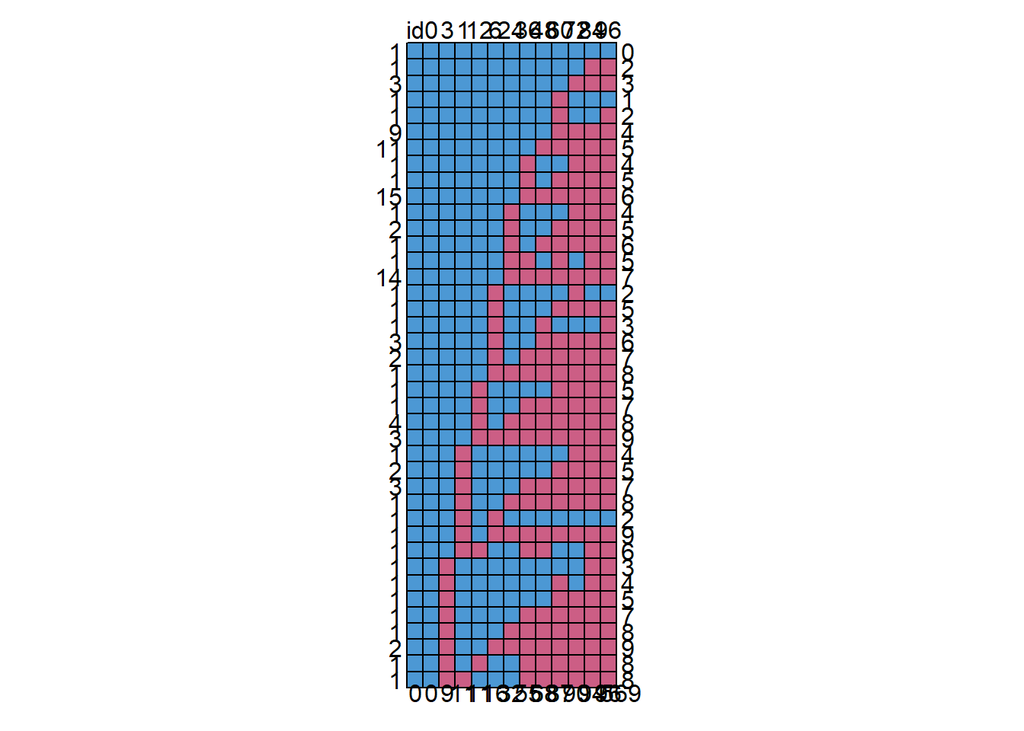

```
##    id 0 3  1 12  6 24 36 48 60 72 84 96
## 1   1 1 1  1  1  1  1  1  1  1  1  1  1   0
## 1   1 1 1  1  1  1  1  1  1  1  1  0  0   2
## 3   1 1 1  1  1  1  1  1  1  1  0  0  0   3
## 1   1 1 1  1  1  1  1  1  1  0  1  1  1   1
## 1   1 1 1  1  1  1  1  1  1  0  1  1  0   2
## 9   1 1 1  1  1  1  1  1  1  0  0  0  0   4
## 11  1 1 1  1  1  1  1  1  0  0  0  0  0   5
## 1   1 1 1  1  1  1  1  0  1  1  0  0  0   4
## 1   1 1 1  1  1  1  1  0  1  0  0  0  0   5
## 15  1 1 1  1  1  1  1  0  0  0  0  0  0   6
## 1   1 1 1  1  1  1  0  1  1  1  0  0  0   4
## 2   1 1 1  1  1  1  0  1  1  0  0  0  0   5
## 1   1 1 1  1  1  1  0  1  0  0  0  0  0   6
## 1   1 1 1  1  1  1  0  0  1  0  1  0  0   5
```

[output cut: 27 more lines]

```r
#Reshape to wide
bmi_data_W <- reshape2::dcast(bmi_data, id ~ month, value.var = "bmiz")

#Use the mice package to plot missingness patterns
md.pattern(bmi_data_W, plot = T)
```

Fit QLS with AR(1) Structure: using sandwich errors as qlspack only provides 4 types of errors (sandwich robust, approximate jacknife, 1-step jacknife, and fully iterated jacknife)

```r
qls_ar1 <- qls(bmiz ~ month + I(month^2), data = bmi_data, id = bmi_data$id, family = "gaussian", correlation = "ar1", std.err = "san.se")
  #for the id argument, have to specify dataset$id, not just id as is typical for other regressions in R
  #for this model I specified sandwich standard errors because there is no model-based option
summary(qls_ar1)
```

```
##
## Call:
## qls(formula = bmiz ~ month + I(month^2), data = bmi_data, id = bmi_data$id,
##     family = "gaussian", correlation = "ar1", std.err = "san.se")
##
##  Coefficients:
##               Estimate    Std.err   Wald Pr(>|W|)
## (Intercept)  5.269e-01  1.165e-01 20.442 6.15e-06 ***
## month        9.940e-03  4.332e-03  5.265   0.0218 *
## I(month^2)  -1.201e-04  5.276e-05  5.186   0.0228 *
## ---
## Signif. codes:  0 '***' 0.001 '**' 0.01 '*' 0.05 '.' 0.1 ' ' 1
##
## Correlation structure = ar1
## Estimated Scale Parameters:
##
##             Estimate Std.err
## (Intercept)     1.59    0.18
##   Link = identity
##
## Estimated Correlation Parameters:
##         Estimate Std.err
## alpha:1   0.8637       0
## Number of clusters:   100  Maximum cluster size: 12
```

```r
#The function for the estimated correlation matrix still works on qls models - we need to specify the fitting.package as "geepack" because qlspack is built to use functions from geepack
createCorrelationMatrixR(qls_ar1, model.corstr = "ar1", fitting.package = "geepack")
```

```
##         t1     t2     t3     t4     t5     t6     t7     t8     t9    t10
## t1  1.0000 0.8637 0.7460 0.6443 0.5565 0.4806 0.4151 0.3585 0.3096 0.2674
## t2  0.8637 1.0000 0.8637 0.7460 0.6443 0.5565 0.4806 0.4151 0.3585 0.3096
## t3  0.7460 0.8637 1.0000 0.8637 0.7460 0.6443 0.5565 0.4806 0.4151 0.3585
## t4  0.6443 0.7460 0.8637 1.0000 0.8637 0.7460 0.6443 0.5565 0.4806 0.4151
## t5  0.5565 0.6443 0.7460 0.8637 1.0000 0.8637 0.7460 0.6443 0.5565 0.4806
## t6  0.4806 0.5565 0.6443 0.7460 0.8637 1.0000 0.8637 0.7460 0.6443 0.5565
## t7  0.4151 0.4806 0.5565 0.6443 0.7460 0.8637 1.0000 0.8637 0.7460 0.6443
## t8  0.3585 0.4151 0.4806 0.5565 0.6443 0.7460 0.8637 1.0000 0.8637 0.7460
## t9  0.3096 0.3585 0.4151 0.4806 0.5565 0.6443 0.7460 0.8637 1.0000 0.8637
## t10 0.2674 0.3096 0.3585 0.4151 0.4806 0.5565 0.6443 0.7460 0.8637 1.0000
## t11 0.2310 0.2674 0.3096 0.3585 0.4151 0.4806 0.5565 0.6443 0.7460 0.8637
## t12 0.1995 0.2310 0.2674 0.3096 0.3585 0.4151 0.4806 0.5565 0.6443 0.7460
##        t11    t12
## t1  0.2310 0.1995
## t2  0.2674 0.2310
## t3  0.3096 0.2674
## t4  0.3585 0.3096
## t5  0.4151 0.3585
## t6  0.4806 0.4151
## t7  0.5565 0.4806
## t8  0.6443 0.5565
## t9  0.7460 0.6443
## t10 0.8637 0.7460
## t11 1.0000 0.8637
## t12 0.8637 1.0000
```

Drop some data so that some subjects have only 1 measurement

```r
#Remove obs with month>0 and id>40
bmi_edit <- bmi_data %>% arrange(id, month) %>% filter(!(month>0 & id>40))

summary(bmi_edit %>% count(id))[,2]
```

```
##
## "Min.   : 1.00  " "1st Qu.: 1.00  " "Median : 1.00  " "Mean   : 3.24  "
##
## "3rd Qu.: 6.25  " "Max.   :12.00  "
```

```r
#Now the min number of observations per person is 1
```

Fit QLS GEE again with AR(1) structure (using sandwich SE as no model-based available)

```r
qls_ar1_drop <- qls(bmiz ~ month + I(month^2), data = bmi_edit, id = bmi_edit$id, family = "gaussian", correlation = "ar1", std.err = "san.se")

summary(qls_ar1_drop)
```

```
##
## Call:
## qls(formula = bmiz ~ month + I(month^2), data = bmi_edit, id = bmi_edit$id,
##     family = "gaussian", correlation = "ar1", std.err = "san.se")
##
##  Coefficients:
##              Estimate   Std.err Wald Pr(>|W|)
## (Intercept)  2.38e-01  1.33e-01 3.21    0.073 .
## month        1.12e-02  7.04e-03 2.53    0.112
## I(month^2)  -8.27e-05  6.87e-05 1.45    0.229
## ---
## Signif. codes:  0 '***' 0.001 '**' 0.01 '*' 0.05 '.' 0.1 ' ' 1
##
## Correlation structure = ar1
## Estimated Scale Parameters:
##
##             Estimate Std.err
## (Intercept)     1.93   0.213
##   Link = identity
##
## Estimated Correlation Parameters:
##         Estimate Std.err
## alpha:1    0.864       0
## Number of clusters:   100  Maximum cluster size: 12
```

```r
#We can see the the number of groups is still 100, and the max obs per group is still 12

nrow(qls_ar1_drop$data) #number of observations used in modeling
```

```
## [1] 324
```

```r
summary(qls_ar1_drop$data %>% count(id))[,2] #Can get summary stats on obs per id directly from the data used in modeling
```

```
##
## "Min.   : 1.00  " "1st Qu.: 1.00  " "Median : 1.00  " "Mean   : 3.24  "
##
## "3rd Qu.: 6.25  " "Max.   :12.00  "
```

Fit GEE with AR(1) structure on edited data (using sandwich SE as no model-based available)

```r
gee_ar1 <- geeglm(bmiz ~ month + I(month^2), id = id, corstr = "ar1", data = bmi_edit)
summary(gee_ar1)
```

```
##
## Call:
## geeglm(formula = bmiz ~ month + I(month^2), data = bmi_edit,
##     id = id, corstr = "ar1")
##
##  Coefficients:
##              Estimate   Std.err Wald Pr(>|W|)
## (Intercept)  2.28e-01  1.33e-01 2.93    0.087 .
## month        8.11e-03  6.84e-03 1.41    0.236
## I(month^2)  -6.39e-05  6.49e-05 0.97    0.325
## ---
## Signif. codes:  0 '***' 0.001 '**' 0.01 '*' 0.05 '.' 0.1 ' ' 1
##
## Correlation structure = ar1
## Estimated Scale Parameters:
##
##             Estimate Std.err
## (Intercept)     1.99   0.225
##   Link = identity
##
## Estimated Correlation Parameters:
##       Estimate Std.err
## alpha    0.902  0.0221
## Number of clusters:   100  Maximum cluster size: 12
```

```r
#number of clusters is still 100, looks like this does not drop subjects with only one observation as in stata
```

Compare model output

```r
#QLS on edited data with sandwich SE
print(summary(qls_ar1_drop)$coefficients)
```

```
##              Estimate  Std.err Wald Pr(>|W|)
## (Intercept)  2.38e-01 1.33e-01 3.21   0.0732
## month        1.12e-02 7.04e-03 2.53   0.1115
## I(month^2)  -8.27e-05 6.87e-05 1.45   0.2286
```

```r
qls_ar1_drop$geese$alpha
```

```
## alpha:1
##   0.864
```

```r
#GEE (geepack) on edited data with sandwich SE
print(summary(gee_ar1)$coefficients)
```

```
##              Estimate  Std.err Wald Pr(>|W|)
## (Intercept)  2.28e-01 1.33e-01 2.93   0.0868
## month        8.11e-03 6.84e-03 1.41   0.2357
## I(month^2)  -6.39e-05 6.49e-05 0.97   0.3247
```

```r
gee_ar1$geese$alpha
```

```
## alpha
## 0.902
```

```r
#Results are pretty similar, alphas vary a bit
```

Fit GEE with AR(1) structure on edited data using the GEE package (to see if it performs differently from the geepack package)

```r
#gee_arm <- gee::gee(bmiz ~ month + I(month^2), id = id, corstr = "AR-M", data = bmi_edit)
gee_error <- ("Beginning Cgee S-function, @(#) geeformula.q 4.13 98/01/27
running glm to get initial regression estimate
(Intercept)       month  I(month^2)
   0.551498    0.026798   -0.000249
Error in gee::gee(bmiz ~ month + I(month^2), id = id, corstr = AR-M,  :
  cgee: M-dependence, M=1, but clustsize=1
fatal error for this model")
print(gee_error)
```

```
## [1] "Beginning Cgee S-function, @(#) geeformula.q 4.13 98/01/27\nrunning glm to get initial regression estimate\n(Intercept)       month  I(month^2) \n   0.551498    0.026798   -0.000249 \nError in gee::gee(bmiz ~ month + I(month^2), id = id, corstr = AR-M,  : \n  cgee: M-dependence, M=1, but clu…
```

```r
#the GEE package can't handle subjects with only one observation
```

Removing subjects with one observations in the data manually to check the results using the GEE package

```r
#Get a list of IDs with only one observation in our edited data
bmi_edit_counts <- bmi_edit %>% count(id) %>% filter(n==1)

#Creating a new dataframe excluding IDs with only only observation in bmi_edit
bmi_edit2 <- bmi_edit %>% filter(!id %in% bmi_edit_counts$id)

#How many observations are we left with
nrow(bmi_edit2)
```

```
## [1] 258
```

```r
#Try fitting GEE using GEE package again after removing those with only one observation
gee_arm <- gee::gee(bmiz ~ month + I(month^2), id = id, corstr = "AR-M", data = bmi_edit2)
```

```
## Beginning Cgee S-function, @(#) geeformula.q 4.13 98/01/27
```

```
## running glm to get initial regression estimate
```

```
## (Intercept)       month  I(month^2)
##    9.30e-01    6.52e-03   -4.78e-05
```

```r
P_table(gee_arm, 5) #from the functions.R file
```

```
##             Estimate Naive S.E. Naive z Robust S.E. Robust z model_based_p
## (Intercept)  0.78253    0.20131   3.887     0.19309    4.053        0.0001
## month        0.00350    0.00892   0.392     0.00674    0.519        0.6952
## I(month^2)  -0.00003    0.00011  -0.303     0.00007   -0.481        0.7617
##             sandwich_based_p
## (Intercept)          0.00005
## month                0.60399
## I(month^2)           0.63041
```

Bonus, equivalent to xtset in R

```r
library(plm)
plm::is.pbalanced(bmi_data$id, bmi_data$month)
```

```
## [1] FALSE
```